# Bike Sharing Regression Exercise

Replication code

Deyu Wang (5796695)

10 November 2026

```r
library(tidyverse)
library(broom)
library(knitr)
```

```r
r1 <- function(x) formatC(x, format = "f", digits = 1)
r2 <- function(x) formatC(x, format = "f", digits = 2)
fmt_p <- function(p) {
  if (p < .001) "< .001" else paste0("= ", sub("^0", "", sprintf("%.3f", p)))
}
# one row of a regression table (estimate, CI, t, p) for one predictor
coef_row <- function(model, x) tidy(model, conf.int = TRUE) %>% filter(term == x)
```

# 1. Read the data

```r
days <- read_csv("day.csv")
days
```

```
## # A tibble: 731 × 16
##    instant dteday     season    yr  mnth holiday weekday workingday weathersit
##      <dbl> <date>      <dbl> <dbl> <dbl>   <dbl>   <dbl>      <dbl>      <dbl>
##  1       1 2011-01-01      1     0     1       0       6          0          2
##  2       2 2011-01-02      1     0     1       0       0          0          2
##  3       3 2011-01-03      1     0     1       0       1          1          1
##  4       4 2011-01-04      1     0     1       0       2          1          1
##  5       5 2011-01-05      1     0     1       0       3          1          1
##  6       6 2011-01-06      1     0     1       0       4          1          1
##  7       7 2011-01-07      1     0     1       0       5          1          2
##  8       8 2011-01-08      1     0     1       0       6          0          2
##  9       9 2011-01-09      1     0     1       0       0          0          1
## 10      10 2011-01-10      1     0     1       0       1          1          1
## # ℹ 721 more rows
## # ℹ 7 more variables: temp <dbl>, atemp <dbl>, hum <dbl>, windspeed <dbl>,
## #   casual <dbl>, registered <dbl>, cnt <dbl>
```

There are 731 days, from 01 January 2011 to 31 December 2012.

# 2. Data dictionary

| Variable | Description |
| --- | --- |
| `instant` | Row index |
| `dteday` | Date |
| `season` | Season (1 = spring, 2 = summer, 3 = fall, 4 = winter) |
| `yr` | Year (0 = 2011, 1 = 2012) |
| `mnth` | Month (1 to 12) |
| `holiday` | 1 if the day is a holiday |
| `weekday` | Day of the week (0 = Sunday) |
| `workingday` | 1 if the day is neither a weekend nor a holiday |
| `weathersit` | Weather (1 = clear or partly cloudy, 2 = mist or cloudy, 3 = light rain or snow, 4 = heavy rain, snow or fog) |
| `temp` | Normalised temperature, (t - t_min) / (t_max - t_min) with t_min = -8 and t_max = 39 °C |
| `atemp` | Normalised “feels like” temperature, t_min = -16 and t_max = 50 °C |
| `hum` | Humidity divided by 100 |
| `windspeed` | Wind speed divided by 67 (the maximum) |
| `casual` | Number of rentals by casual users |
| `registered` | Number of rentals by registered users |
| `cnt` | Total number of rentals (casual + registered) |

# 3. Unnormalised temperature and wind speed

Reversing the normalisation: temperature = -8 + (39 - (-8)) × `temp`, and wind speed = 67 × `windspeed`.

```r
days <- days %>%
  mutate(temp.in.C = -8 + (39 - (-8)) * temp,
         windspeed.in.mph = windspeed * 67)

descriptives <- days %>%
  select(cnt, temp.in.C, windspeed.in.mph) %>%
  pivot_longer(everything(), names_to = "variable") %>%
  group_by(variable) %>%
  summarise(mean = mean(value), sd = sd(value),
            min = min(value), max = max(value))
kable(descriptives, digits = 1)
```

| variable | mean | sd | min | max |
| --- | --- | --- | --- | --- |
| cnt | 4504.3 | 1937.2 | 22.0 | 8714.0 |
| temp.in.C | 15.3 | 8.6 | -5.2 | 32.5 |
| windspeed.in.mph | 12.8 | 5.2 | 1.5 | 34.0 |

# 4. Univariate plots

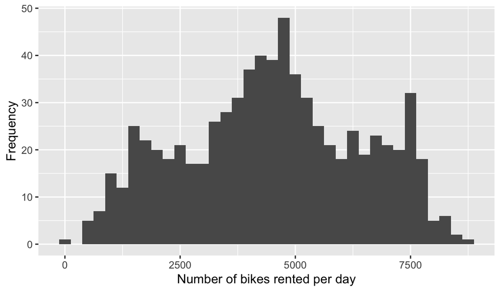

```r
ggplot(days, aes(x = cnt)) +
  geom_histogram(binwidth = 250) +
  labs(x = "Number of bikes rented per day", y = "Frequency")
```

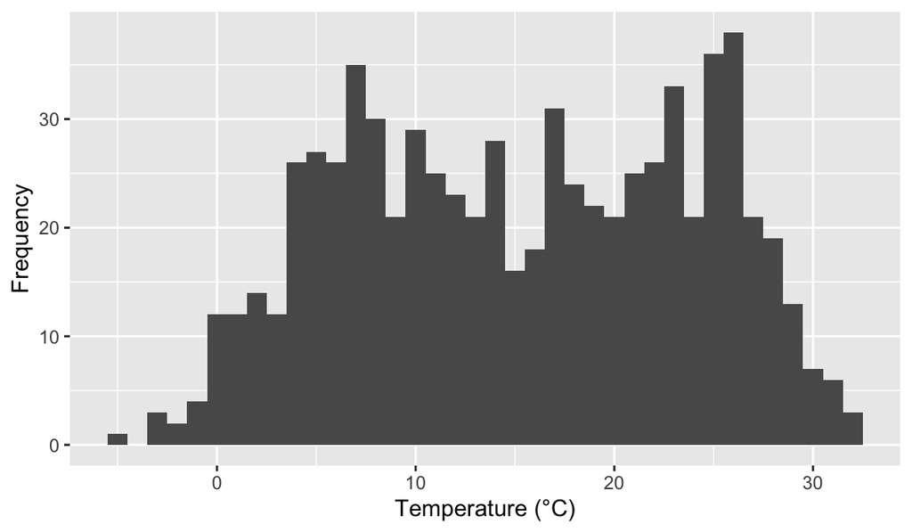

```r
ggplot(days, aes(x = temp.in.C)) +
  geom_histogram(binwidth = 1) +
  labs(x = "Temperature (°C)", y = "Frequency")
```

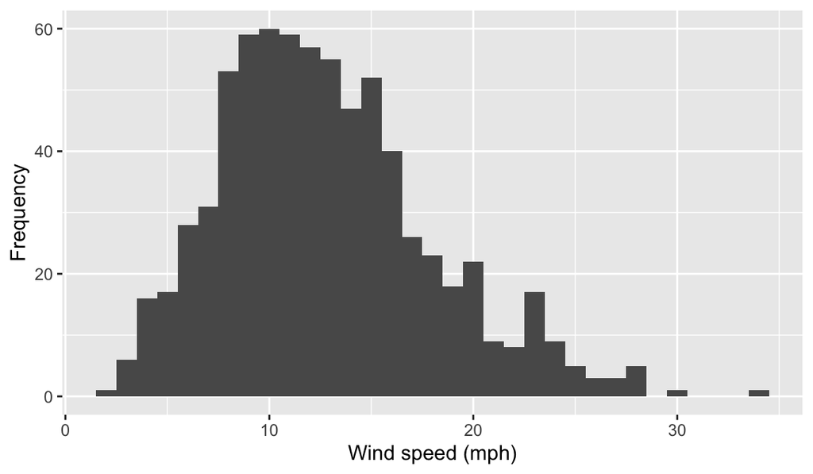

```r
ggplot(days, aes(x = windspeed.in.mph)) +
  geom_histogram(binwidth = 1) +
  labs(x = "Wind speed (mph)", y = "Frequency")
```

Rentals are spread fairly evenly between about 1,000 and 8,000 a day. Temperature covers -5.2 to 32.5 °C. Wind speed is right skewed, with most days between 5 and 20 mph.

# 5. Bivariate plots

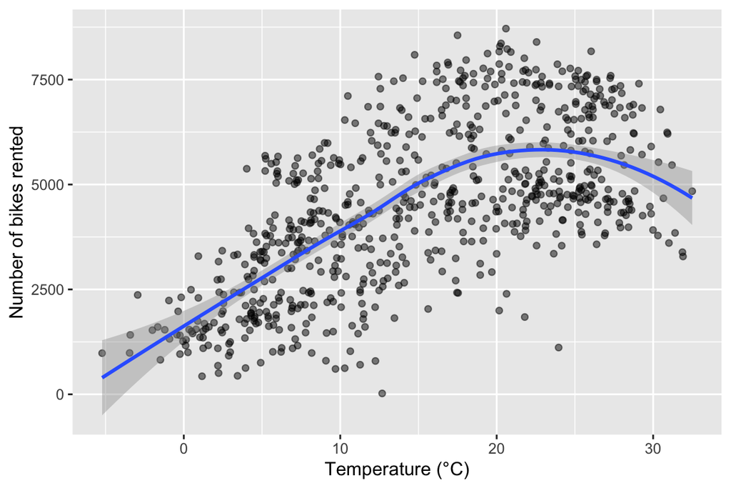

```r
ggplot(days, aes(x = temp.in.C, y = cnt)) +
  geom_point(alpha = 0.5) +
  geom_smooth() +
  labs(x = "Temperature (°C)", y = "Number of bikes rented")
```

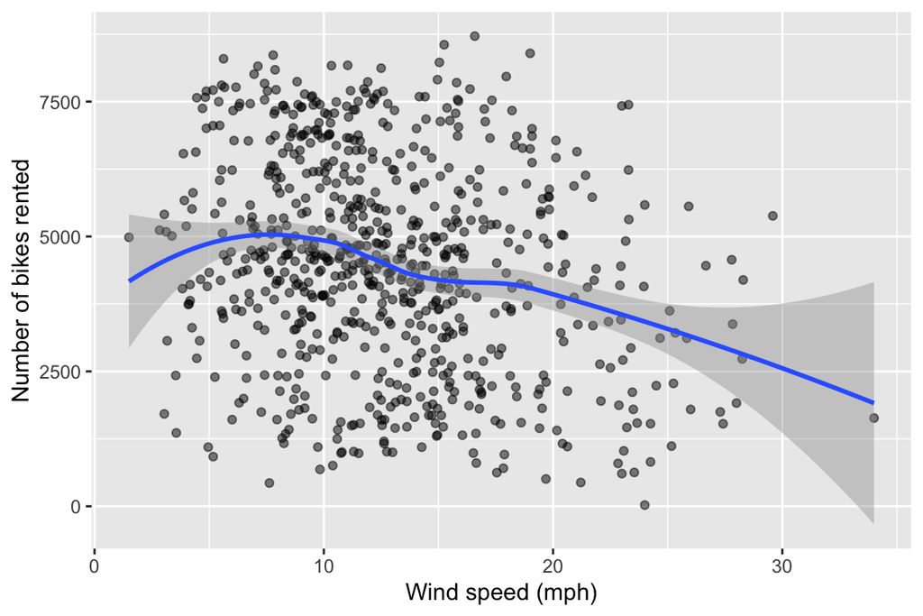

```r
ggplot(days, aes(x = windspeed.in.mph, y = cnt)) +
  geom_point(alpha = 0.5) +
  geom_smooth() +
  labs(x = "Wind speed (mph)", y = "Number of bikes rented")
```

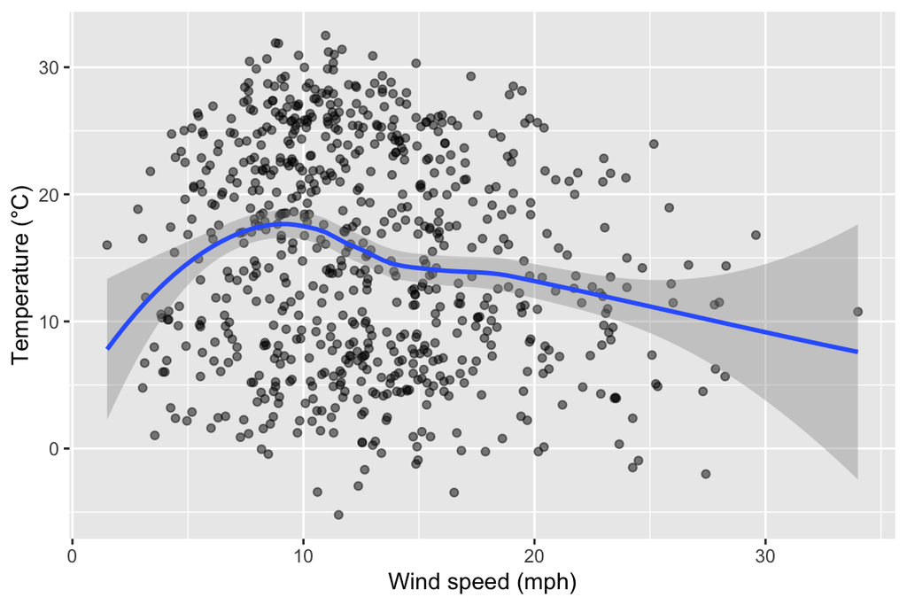

```r
ggplot(days, aes(x = windspeed.in.mph, y = temp.in.C)) +
  geom_point(alpha = 0.5) +
  geom_smooth() +
  labs(x = "Wind speed (mph)", y = "Temperature (°C)")
```

Rentals go up with temperature, but the curve flattens off and turns down at the hottest temperatures. Rentals go down a little as wind speed goes up. Temperature and wind speed are not strongly related.

# 6. Correlations

```r
cors <- cor(select(days, cnt, temp.in.C, windspeed.in.mph))
round(cors, 2)
```

```
##                    cnt temp.in.C windspeed.in.mph
## cnt               1.00      0.63            -0.23
## temp.in.C         0.63      1.00            -0.16
## windspeed.in.mph -0.23     -0.16             1.00
```

The correlation between temperature and wind speed is only -0.16. This is good because it means the two predictors are not very collinear. If they were highly correlated, the regression could not separate the effect of one from the effect of the other, and the coefficients in the multiple regression would have large standard errors and be unstable.

# 7. Regressions

```r
m.cnt.by.windspeed <- lm(cnt ~ windspeed.in.mph, data = days)
m.cnt.by.temp <- lm(cnt ~ temp.in.C, data = days)
m.cnt.by.windspeed.temp <- lm(cnt ~ windspeed.in.mph + temp.in.C, data = days)

summary(m.cnt.by.windspeed)
```

```
##
## Call:
## lm(formula = cnt ~ windspeed.in.mph, data = days)
##
## Residuals:
##     Min      1Q  Median      3Q     Max
## -4522.7 -1374.7   -74.6  1461.8  4544.0
##
## Coefficients:
##                  Estimate Std. Error t value Pr(>|t|)
## (Intercept)       5621.15     185.06  30.374  < 2e-16 ***
## windspeed.in.mph   -87.51      13.43  -6.514 1.36e-10 ***
## ---
## Signif. codes:  0 '***' 0.001 '**' 0.01 '*' 0.05 '.' 0.1 ' ' 1
##
## Residual standard error: 1884 on 729 degrees of freedom
## Multiple R-squared:  0.05501,    Adjusted R-squared:  0.05372
## F-statistic: 42.44 on 1 and 729 DF,  p-value: 1.36e-10
```

```r
cbind(coef(m.cnt.by.windspeed), confint(m.cnt.by.windspeed))
```

```
##                                 2.5 %     97.5 %
## (Intercept)      5621.15288 5257.8341 5984.47169
## windspeed.in.mph  -87.50616 -113.8775  -61.13485
```

```r
summary(m.cnt.by.temp)
```

```
##
## Call:
## lm(formula = cnt ~ temp.in.C, data = days)
##
## Residuals:
##     Min      1Q  Median      3Q     Max
## -4615.3 -1134.9  -104.4  1044.3  3737.8
##
## Coefficients:
##             Estimate Std. Error t value Pr(>|t|)
## (Intercept) 2344.976    113.864   20.59   <2e-16 ***
## temp.in.C    141.292      6.493   21.76   <2e-16 ***
## ---
## Signif. codes:  0 '***' 0.001 '**' 0.01 '*' 0.05 '.' 0.1 ' ' 1
##
## Residual standard error: 1509 on 729 degrees of freedom
## Multiple R-squared:  0.3937, Adjusted R-squared:  0.3929
## F-statistic: 473.5 on 1 and 729 DF,  p-value: < 2.2e-16
```

```r
cbind(coef(m.cnt.by.temp), confint(m.cnt.by.temp))
```

```
##                           2.5 %    97.5 %
## (Intercept) 2344.9757 2121.4360 2568.5155
## temp.in.C    141.2917  128.5438  154.0396
```

```r
summary(m.cnt.by.windspeed.temp)
```

```
##
## Call:
## lm(formula = cnt ~ windspeed.in.mph + temp.in.C, data = days)
##
## Residuals:
##     Min      1Q  Median      3Q     Max
## -3929.7 -1138.7  -138.2  1051.8  3877.6
##
## Coefficients:
##                  Estimate Std. Error t value Pr(>|t|)
## (Intercept)      3081.860    189.396  16.272  < 2e-16 ***
## windspeed.in.mph  -51.822     10.733  -4.828 1.68e-06 ***
## temp.in.C         136.352      6.478  21.050  < 2e-16 ***
## ---
## Signif. codes:  0 '***' 0.001 '**' 0.01 '*' 0.05 '.' 0.1 ' ' 1
##
## Residual standard error: 1487 on 728 degrees of freedom
## Multiple R-squared:  0.4126, Adjusted R-squared:  0.4109
## F-statistic: 255.6 on 2 and 728 DF,  p-value: < 2.2e-16
```

```r
cbind(coef(m.cnt.by.windspeed.temp), confint(m.cnt.by.windspeed.temp))
```

```
##                                  2.5 %     97.5 %
## (Intercept)      3081.86049 2710.03206 3453.68891
## windspeed.in.mph  -51.82247  -72.89344  -30.75149
## temp.in.C         136.35182  123.63498  149.06867
```

All three models in one table (this is Table 1 in the write-up):

```r
models <- list(`Wind speed only` = m.cnt.by.windspeed,
               `Temperature only` = m.cnt.by.temp,
               `Wind speed and temperature` = m.cnt.by.windspeed.temp)

coef.table <- map_dfr(models, ~ tidy(.x, conf.int = TRUE), .id = "model") %>%
  mutate(cell = paste0(r1(estimate), " [", r1(conf.low), ", ", r1(conf.high), "]"),
         term = recode(term, `(Intercept)` = "Intercept",
                       windspeed.in.mph = "Wind speed (mph)",
                       temp.in.C = "Temperature (°C)")) %>%
  select(model, term, cell) %>%
  pivot_wider(names_from = model, values_from = cell, values_fill = "")

fit.table <- tibble(term = "R²", !!!map(models, ~ r2(summary(.x)$r.squared)))

table.1 <- bind_rows(coef.table, fit.table) %>% rename(` ` = term)
kable(table.1)
```

|  | Wind speed only | Temperature only | Wind speed and temperature |
| --- | --- | --- | --- |
| Intercept | 5621.2 [5257.8, 5984.5] | 2345.0 [2121.4, 2568.5] | 3081.9 [2710.0, 3453.7] |
| Wind speed (mph) | -87.5 [-113.9, -61.1] |  | -51.8 [-72.9, -30.8] |
| Temperature (°C) |  | 141.3 [128.5, 154.0] | 136.4 [123.6, 149.1] |
| R² | 0.06 | 0.39 | 0.41 |

# 8. Effect of temperature

From the temperature only model, each extra degree C goes with 141.3 more bikes rented per day, 95% CI [128.5, 154.0], *t*(729) = 21.76, *p* < .001.

# 9. Effect of wind speed

From the wind speed only model, each extra mph of wind goes with 87.5 fewer bikes rented per day, 95% CI [61.1, 113.9], *t*(729) = -6.51, *p* < .001.

# 10. Temperature, holding wind speed constant

Holding wind speed constant, each extra degree C goes with 136.4 more bikes, 95% CI [123.6, 149.1], *t*(728) = 21.05, *p* < .001. This is close to the estimate from the temperature only model.

# 11. Wind speed, holding temperature constant

Holding temperature constant, each extra mph of wind goes with 51.8 fewer bikes, 95% CI [30.8, 72.9], *t*(728) = -4.83, *p* < .001. This is smaller than the 87.5 from the wind speed only model.

# 12. Why the wind speed estimate changes

```r
m.temp.by.windspeed <- lm(temp.in.C ~ windspeed.in.mph, data = days)
coef(m.temp.by.windspeed)
```

```
##      (Intercept) windspeed.in.mph
##       18.6230906       -0.2617031
```

```r
# change in the wind speed coefficient between the two models
coef(m.cnt.by.windspeed)["windspeed.in.mph"] - coef(m.cnt.by.windspeed.temp)["windspeed.in.mph"]
```

```
## windspeed.in.mph
##        -35.68369
```

```r
# temperature coefficient x how much colder windy days are
coef(m.cnt.by.windspeed.temp)["temp.in.C"] * coef(m.temp.by.windspeed)["windspeed.in.mph"]
```

```
## temp.in.C
## -35.68369
```

Windy days tend to be colder days: each extra mph of wind goes with 0.26 °C lower temperature on average. Cold days have fewer rentals. When temperature is left out of the model, the wind speed coefficient picks up part of the effect of temperature, so it looks bigger than it is. Once temperature is in the model, wind speed is compared at the same temperature and its coefficient gets smaller. The two numbers above are the same, which shows the whole change in the wind speed coefficient comes from its link with temperature.

The temperature coefficient hardly changes because wind speed has a much smaller effect, so leaving it out does not bias temperature much. Because the correlation between the predictors is low, both coefficients stay fairly precise in the multiple regression.

# 13. Temperature or wind speed?

```r
r.sq <- map_dbl(models, ~ summary(.x)$r.squared)
round(r.sq, 3)
```

```
##            Wind speed only           Temperature only
##                      0.055                      0.394
## Wind speed and temperature
##                      0.413
```

Temperature on its own explains 39.4% of the variance in daily rentals, while wind speed on its own explains only 5.5%. Adding wind speed to temperature only raises R² by 1.9 percentage points. Temperature matters much more, so if I could only know one variable I would want to know the temperature. Wind speed still has an effect when temperature is held constant (its CI does not include zero).

# 14. Temperature effect by month

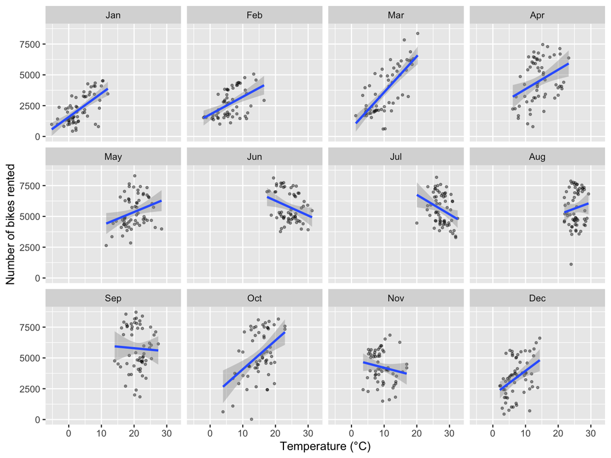

```r
days <- days %>%
  mutate(month = factor(mnth, levels = 1:12, labels = month.abb))

figure.1 <- ggplot(days, aes(x = temp.in.C, y = cnt)) +
  geom_point(alpha = 0.4, size = 0.8) +
  geom_smooth(method = "lm") +
  facet_wrap(~ month) +
  labs(x = "Temperature (°C)", y = "Number of bikes rented")
figure.1
```

Test whether the temperature slope is different in different months (temperature × month interaction):

```r
m.cnt.by.temp.month <- lm(cnt ~ temp.in.C * month, data = days)
anova(m.cnt.by.temp.month)
```

```
## Analysis of Variance Table
##
## Response: cnt
##                  Df     Sum Sq    Mean Sq  F value    Pr(>F)
## temp.in.C         1 1078688585 1078688585 561.1490 < 2.2e-16 ***
## month            11  145704834   13245894   6.8907 4.157e-11 ***
## temp.in.C:month  11  156086167   14189652   7.3817 4.794e-12 ***
## Residuals       707 1359055806    1922285
## ---
## Signif. codes:  0 '***' 0.001 '**' 0.01 '*' 0.05 '.' 0.1 ' ' 1
```

The interaction is significant, *F*(11, 707) = 7.38, *p* < .001, so the effect of temperature depends on the month.

Temperature slope for each month (same model, written so that each coefficient is the slope for one month):

```r
m.slopes <- lm(cnt ~ 0 + month + month:temp.in.C, data = days)

month.slopes <- tidy(m.slopes, conf.int = TRUE) %>%
  filter(str_detect(term, ":temp.in.C")) %>%
  mutate(month = str_remove_all(term, "month|:temp.in.C")) %>%
  select(month, estimate, conf.low, conf.high, p.value)

kable(month.slopes, digits = c(0, 1, 1, 1, 3))
```

| month | estimate | conf.low | conf.high | p.value |
| --- | --- | --- | --- | --- |
| Jan | 192.2 | 103.1 | 281.3 | 0.000 |
| Feb | 143.7 | 51.9 | 235.5 | 0.002 |
| Mar | 291.5 | 220.6 | 362.3 | 0.000 |
| Apr | 157.6 | 71.2 | 244.0 | 0.000 |
| May | 109.8 | 8.2 | 211.4 | 0.034 |
| Jun | -120.0 | -234.1 | -5.9 | 0.039 |
| Jul | -158.3 | -301.0 | -15.5 | 0.030 |
| Aug | 97.9 | -87.9 | 283.6 | 0.301 |
| Sep | -24.9 | -146.7 | 96.8 | 0.688 |
| Oct | 234.2 | 146.0 | 322.5 | 0.000 |
| Nov | -69.4 | -186.2 | 47.5 | 0.244 |
| Dec | 198.4 | 89.1 | 307.7 | 0.000 |

In the colder months (October to May, apart from November) warmer days have more rentals and the confidence intervals do not include zero, for example 291.5 more bikes per °C in March. In June and July the slope is negative (-120.0 and -158.3 bikes per °C), so on days that are already hot, extra heat means fewer rentals. For August, September and November the confidence intervals include zero. This matches the curve in the scatterplot in question 5: rentals rise with temperature up to the mid 20s °C and then level off or fall.

# Other things to note

```r
days %>% group_by(yr) %>% summarise(mean.cnt = mean(cnt))
```

```
## # A tibble: 2 × 2
##      yr mean.cnt
##   <dbl>    <dbl>
## 1     0    3406.
## 2     1    5600.
```

Rentals were much higher in 2012 than in 2011, and rain, humidity and working days also affect rentals. None of these are in the models above. The data are observational, so the coefficients are associations rather than causal effects.